# Practical Machine Learning Course Project

Steve Petersen

June 17, 2015

## Background

Using devices such as Jawbone Up, Nike FuelBand, and Fitbit it is now possible to collect a large amount of data about personal activity relatively inexpensively. These type of devices are part of the quantified self movement – a group of enthusiasts who take measurements about themselves regularly to improve their health, to find patterns in their behavior, or because they are tech geeks. One thing that people regularly do is quantify how much of a particular activity they do, but they rarely quantify how well they do it. In this project, your goal will be to use data from accelerometers on the belt, forearm, arm, and dumbell of 6 participants. They were asked to perform barbell lifts correctly and incorrectly in 5 different ways. More information is available from the website here: http://groupware.les.inf.puc-rio.br/har (see the section on the Weight Lifting Exercise Dataset).

## Overview

The goal of this project is to predict the manner in which they did the exercise. This is the “classe” variable in the training set. You may use any of the other variables to predict with. You should create a report describing how you built your model, how you used cross validation, what you think the expected out of sample error is, and why you made the choices you did. You will also use your prediction model to predict 20 different test cases.

## Sensor Data

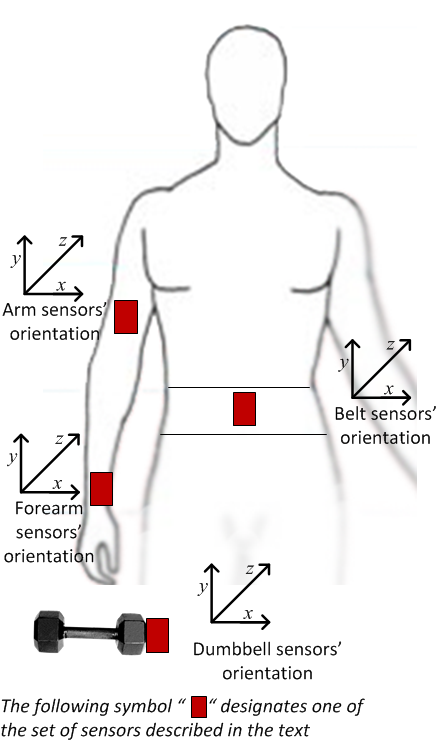

The WLE dataset is from the following paper:

Velloso, E.; Bulling, A.; Gellersen, H.; Ugulino, W.; Fuks, H. Qualitative Activity Recognition of Weight Lifting Exercises. Proceedings of 4th International Conference in Cooperation with SIGCHI (Augmented Human ’13) . Stuttgart, Germany: ACM SIGCHI, 2013.

Read more: http://groupware.les.inf.puc-rio.br/har#ixzz3dLPHjPBw

This human activity recognition research has traditionally focused on discriminating between different activities, i.e. to predict “which” activity was performed at a specific point in time (like with the Daily Living Activities dataset above). The approach we propose for the Weight Lifting Exercises dataset is to investigate “how (well)” an activity was performed by the wearer. The “how (well)” investigation has only received little attention so far, even though it potentially provides useful information for a large variety of applications,such as sports training.

In this work (see the paper) we first define quality of execution and investigate three aspects that pertain to qualitative activity recognition: the problem of specifying correct execution, the automatic and robust detection of execution mistakes, and how to provide feedback on the quality of execution to the user. We tried out an on-body sensing approach (dataset here), but also an “ambient sensing approach” (by using Microsoft Kinect - dataset still unavailable)

Six young health participants were asked to perform one set of 10 repetitions of the Unilateral Dumbbell Biceps Curl in five different fashions: exactly according to the specification (Class A), throwing the elbows to the front (Class B), lifting the dumbbell only halfway (Class C), lowering the dumbbell only halfway (Class D) and throwing the hips to the front (Class E).

Class A corresponds to the specified execution of the exercise, while the other 4 classes correspond to common mistakes. Participants were supervised by an experienced weight lifter to make sure the execution complied to the manner they were supposed to simulate. The exercises were performed by six male participants aged between 20-28 years, with little weight lifting experience. We made sure that all participants could easily simulate the mistakes in a safe and controlled manner by using a relatively light dumbbell (1.25kg).

Read more: http://groupware.les.inf.puc-rio.br/har#ixzz3dLOvIVYb

Note: This analysis depends on the following R libraries. Note we also enable parallelism to allow the models to train in a reasonable amount of time. In this case, training the k-fold models takes overnight.

```r
library(caret)
library(AppliedPredictiveModeling)
library(randomForest)
```

```r
library(scatterplot3d)
library(rgl)
library(doParallel)
cl <- makeCluster(detectCores())
registerDoParallel(cl)
set.seed(125)
```

## Retrieve The Data

```r
download.file("https://d396qusza40orc.cloudfront.net/predmachlearn/pml-training.csv
", "training.csv", method="curl")
download.file("https://d396qusza40orc.cloudfront.net/predmachlearn/pml-testing.csv
", "testing.csv", method="curl")
training <- read.csv("training.csv")
testing <- read.csv("testing.csv")
```

## Exploratory Data Analysis

First lets take a look at how complete the data is.

```r
incompleteTrainingColumns <- length(which(colSums(is.na(training)) != 0))
incompleteTestColumns <- length(which(colSums(is.na(testing)) != 0))
```

We can see that we have 67 incomplete columns in our training set and 100 in our test set. Lets remove the union of those columns from the training and testing data - we won’t bother with variables that can’t inform the model or the prediction for all of the training and test cases.

```r
natest <- which(colSums(is.na(testing)) != 0)
natrain <- which(colSums(is.na(training)) != 0)
training.complete <- training[,-union(natest, natrain)]
testing.complete <- testing[,-union(natest, natrain)]
```

Now let’s do some principle component analysis on the data to get a feel for what the model will be sensitive to. First we want to create a “predictor set” out of the numerical sensor data, so let’s get rid of some of the non-numeric data (user name, timestamps, etc.):

```r
notinteresting.columns <- c('X','user_name', 'raw_timestamp_part_1', 'raw_timestamp_part_2', 'cvtd_timestamp', 'new_window', 'num_window')
class.column <- c('classe')
unused.columns <- union(notinteresting.columns, class.column)
```

Now for the PCA analysis on the relevant data:

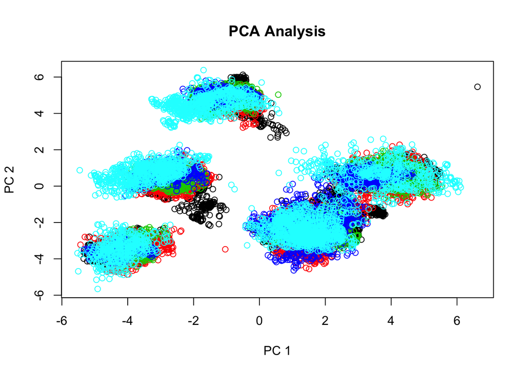

```r
training.predictors <- training.complete[,!(names(training.complete) %in% unused.columns)]
preProc <- preProcess(training.predictors, method=c("BoxCox", "center", "scale", "pca"))
pc <- predict(preProc, training.predictors)
plot(pc$PC1, pc$PC2, col=training.complete$classe, main="PCA Analysis", xlab="PC 1", ylab="PC 2")
```

Basically, there are five clusters in the plot of the two first principle components, however those clusters don’t map to the labels at all, and graphs of the other principle components (not shown, for brevity) don’t show any insights either. So the exploratory analysis doesn’t yield anything interpretable.

## Model Creation

First lets create a k-fold partition of our training data with k = 10…

```r
k <- 10
training.model <- training.complete[,!(names(training.complete) %in% notinteresting.columns)]
training.folds <- createFolds(training.model$classe, k = k, list = FALSE)
```

…then create a vector of Random Forest models on the folds. Note that we don’t keep our preprocessing from the principle component analysis, as decision trees are not sensitive to feature scale/normalization differences.

```r
models <- vector(mode="list", length=k)
for (i in 1:k) {
  models[[i]] <-train(classe~., data=training.model[training.folds != i,], method="rf")
}
```

Let’s plot the values and average of the in-sample accuracy for all of the models.

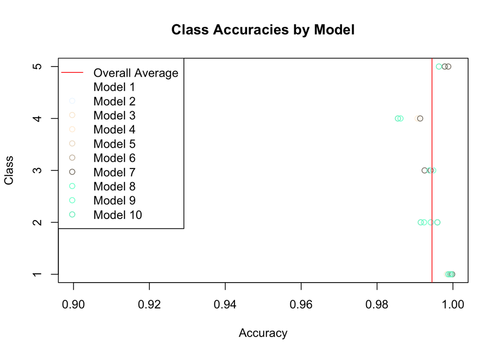

```r
accuracies <- data.frame(classe=training.complete$classe, value=0, model=0)
summ <- 0
for (i in 1:k) {
  for (j in 1:5) {
    accuracies[i*j,1] <- levels(training.complete$classe)[j]
    accuracies[i*j,2] <- 1-models[[i]]$finalModel$confusion[j,6]
    accuracies[i*j,3] <- i
  }
  summ <- summ + sum(models[[i]]$finalModel$confusion[,6])/5
}
avg <- summ / k
palette(topo.colors(10))
plot(accuracies$value, accuracies$classe, ylab="Class", xlab="Accuracy", main="Class Accuracies by Model", col=colors()[accuracies$model], xlim=c(0.9, 1.0))
abline(v=(1-avg), col="red")
legend( x="topleft",
        legend=c("Overall Average","Model 1","Model 2","Model 3","Model 4","Model 5","Model 6","Model 7","Model 8","Model 9","Model 10"),
        col=c("red",colors()[1], colors()[2], colors()[3], colors()[4], colors()[5], colors()[6], colors()[7], colors()[8], colors()[9], colors()[10]), lwd=1, lty=c(1,NA,NA,NA,NA,NA,NA,NA,NA,NA,NA),
        pch=c(NA,1,1,1,1,1,1,1,1,1,1) )
```

We achieve 99.4% overall (across all class values) in-sample accuracy with our models. We expect out-of-sample accuracy to be lower.

## Cross Validation

To cross validate, we predict on the leftover fold for each model created above, storing the confusion matrix for each run.

```r
matrices <- vector(mode="list", length=k)
for (i in 1:k) {
  predCv <- predict(models[[i]], newdata=training.model[training.folds == i,])
  matrices[[i]] <- confusionMatrix(predCv, training.model[training.folds == i,]$classe)
}
```

To estimate out-of-sample error, average the confusion matrix accuracy for all of the runs.

```r
sum <- 0
for (i in 1:k) {
  sum <- sum + matrices[[i]]$overall[1]
}
avg <- sum / k
```

We achieve 99.5% accuracy with our cross-validated models.

## Test Set Prediction

Finally, lets run the test data through the first model in the matrix

```r
testing.model <- testing.complete[,!(names(testing.complete) %in% notinteresting.columns)]
testPredictions <- predict(models[[1]], newdata=testing.model)
tf <- data.frame(problem_id=testing.model$problem_id)
tf$prediction <- testPredictions
```

The predictions for the test cases are :

```r
tf
```

```
##    problem_id prediction
## 1           1          B
## 2           2          A
## 3           3          B
## 4           4          A
## 5           5          A
## 6           6          E
## 7           7          D
## 8           8          B
## 9           9          A
## 10         10          A
## 11         11          B
## 12         12          C
## 13         13          B
## 14         14          A
## 15         15          E
## 16         16          E
## 17         17          A
## 18         18          B
## 19         19          B
## 20         20          B
```

Write these out to files so that they can be submitted:

```r
pml_write_files = function(x) {
  n = length(x)
  for (i in 1:n) {
    filename = paste0("problem_id_", i, ".txt")
    write.table(x[i], file=filename,quote=FALSE,row.names=FALSE,col.names=FALSE)
  }
}
pml_write_files(testPredictions)
```